# Curva de Phillips, ¿sigue siendo válida?

Author

Nosotros

# Intro

Estamos en el tercer día del [curso de Introducción a Quarto](https://perezp44.github.io/intro.to.quarto/) y estamos practicando cómo hacer un tutorial. Como algunos de los asistentes al curso es posible que no sepan mucho R, vamos a replicar y ampliar [este ejemplo](https://twitter.com/ThomIvar/status/1516114838996631563).

# Marco teórico

Nos da un poco igual pero el gráfico de @ThomIvar hace referencia a la **curva de Phillips** que según la Wikipedia es:

> La curva de Phillips, en macroeconomía, representa una curva empírica de pendiente negativa que relaciona la tasa de inflación y la tasa de desempleo. – Articulo de la Wiki [aquí](https://es.wikipedia.org/wiki/Curva_de_Phillips)

Abajo tienes el gráfico que ilustra la Curva de Phillips en la Wikipedia:

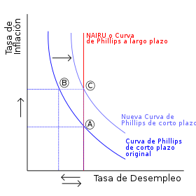

Curva de Phillips en la Wikipedia

Por mucho que me empeñe yo, $y_{t}=A_{1}y_{t-1}+A_{2}y_{t-2}+v_{t}$ no es la ecuación de la Curva de Phillips. Tampoco esta:

$$A(L)=(I_{K}-A_{1}L^{1}-A_{2}L^{2}-...-A_{p}L^{p})$$

# Datos

Antes de iniciar el análisis cargamos los paquetes de R que usaremos, solo que no vas a ver el chunk en el output final porque hemos puesto `#| include: false`.

## Inflación

Descargamos datos de inflación con este código:

```r
url_inflation <- "https://stats.oecd.org/sdmx-json/data/DP_LIVE/.CPI.../OECD?contentType=csv&detail=code&separator=comma&csv-lang=en"
ruta_inflation <- "./datos/DP_LIVE_22032023113248591.csv"
# curl::curl_download(url_inflation, ruta_inflation)
```

## Desempleo

Descargamos datos de desempleo con este código:

```r
url_unemployment <- "https://stats.oecd.org/sdmx-json/data/DP_LIVE/.HUR.../OECD?contentType=csv&detail=code&separator=comma&csv-lang=en"
ruta_unemployment <- "./datos/DP_LIVE_12042023090537614.csv"
# curl::curl_download(url_unemployment, ruta_unemployment)
```

# Resultados

Importamos los datos al `Global env de R`:

```r
inflation_orig    <- readr::read_csv(ruta_inflation)
unemployment_orig <- readr::read_csv(ruta_unemployment)
```

Trabajamos los datos:

```r
#- seleccionamos datos ---------------------------------------------------------
inflation <- inflation_orig %>%
  dplyr::filter(FREQUENCY == "M" & MEASURE == "AGRWTH", SUBJECT == "TOT") %>%
  select(place = LOCATION, date = TIME, cpi = Value)

unemployment <- unemployment_orig %>%
  dplyr::filter(FREQUENCY == 'M', SUBJECT == 'TOT') %>%
  select(place = LOCATION, date = TIME, rate = Value)

#- fusionamos los 2 df's -------------------------------------------------------
df <- left_join(inflation, unemployment) %>%
       tidyr::drop_na() %>%
       dplyr::mutate(group = case_when(
           str_starts(date, "199") ~ "1991-1999",
           str_starts(date, "200") ~ "2000-2009",
           str_starts(date, "201") ~ "2010-2019",
           str_starts(date, "202") ~ ">= 2020",
           TRUE ~ "other" )) %>%
      dplyr::filter(group != "other")
```

Hacemos el plot de [@ThomIvar](https://twitter.com/ThomIvar). Primero el plot básico:

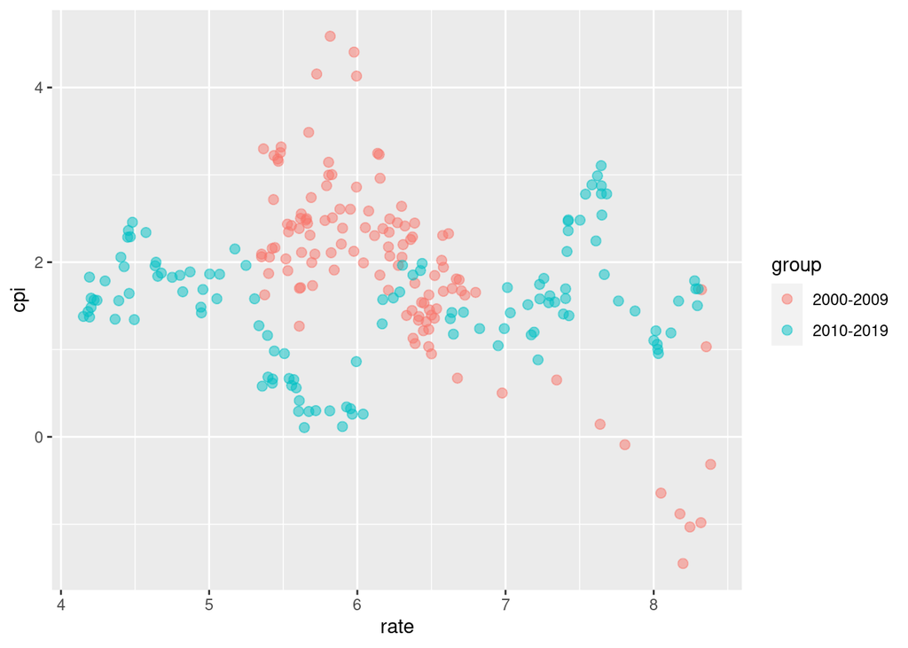

```r
my_country <- c("G-7")  #- seleccionamos "país"
my_periodos <- c("2000-2009", "2010-2019") #- seleccionamos periodos

df_1p <- df %>%
  dplyr::filter(place == my_country) %>%
  dplyr::filter(group %in% my_periodos)


# -- make plot for 1 country
p0 <- ggplot(df_1p, aes(x = rate, y = cpi, group = group, color = group)) +
        geom_point(alpha = 0.5, size = 2.25)
p0
```

Y ahora el super-gráfico:

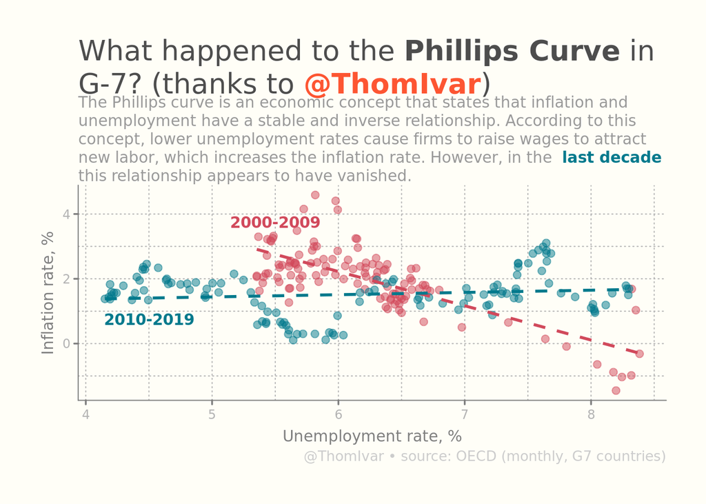

```r
my_title <- glue::glue("What happened to the <b>Phillips Curve</b> in ", my_country  , "? (thanks to <b style='color:#fd5532'>@ThomIvar</b>)")

p1 <- p0 + geom_smooth(method = 'lm', se = FALSE, linetype = 2) +
  scale_color_manual(values = c('#d1495b', '#00798c')) +
  annotate('text', x = 5.5, y = 3.75, label = '2000-2009', color = '#d1495b',
           family = 'American Typewriter', fontface = 'bold') +
  annotate('text', x = 4.5, y = 0.75, label = '2010-2019', color = '#00798c',
           family = 'American Typewriter', fontface = 'bold') +
  labs(title = my_title,
       subtitle = "The Phillips curve is an economic concept that states that inflation
       and unemployment have a stable and inverse relationship. According to this concept,
       lower unemployment rates cause firms to raise wages to attract new labor,
       which increases the inflation rate. However, in the <b style='color:#00798c'>
       last decade</b> this relationship appears to have vanished.",
       caption = '@ThomIvar • source: OECD (monthly, G7 countries)',
       x = 'Unemployment rate, %',
       y = 'Inflation rate, %') +
  theme_void() +
  theme(text = element_text('American Typewriter', color = 'grey30'),
    legend.position = 'none',
    plot.title = element_textbox_simple(size = 20, margin = margin(b = 0.15, unit = 'cm')),
    plot.subtitle = element_textbox_simple(size = 11, color = 'grey60',
                                           margin = margin(b = 0.25, unit = 'cm')),
    plot.background = element_rect(fill = '#fffef7', color = '#fffef7'),
    plot.caption = element_text(size = 10, color = 'grey80'),
    plot.margin = margin(1, 1, 1, 1, 'cm'),
    panel.grid = element_line(color = 'grey70', linetype = 'dotted'),
    axis.title = element_text(margin = margin(t = 0.2, r = 0.2, unit = 'cm'), color = 'grey50'),
    axis.title.y = element_text(angle = 90),
    axis.text = element_text(color = 'grey70', size = 9,
                             margin = margin(t = 0.1, r = 0.1, unit = 'cm')),
    axis.line = element_line(color = 'grey50'),
    axis.ticks = element_line(color = 'grey50', size = 0.6),
    axis.ticks.length = unit(0.10, 'cm'))
p1
```

# Más resultados

Por hacer algo nuevo vamos a hacer un faceted-graph:

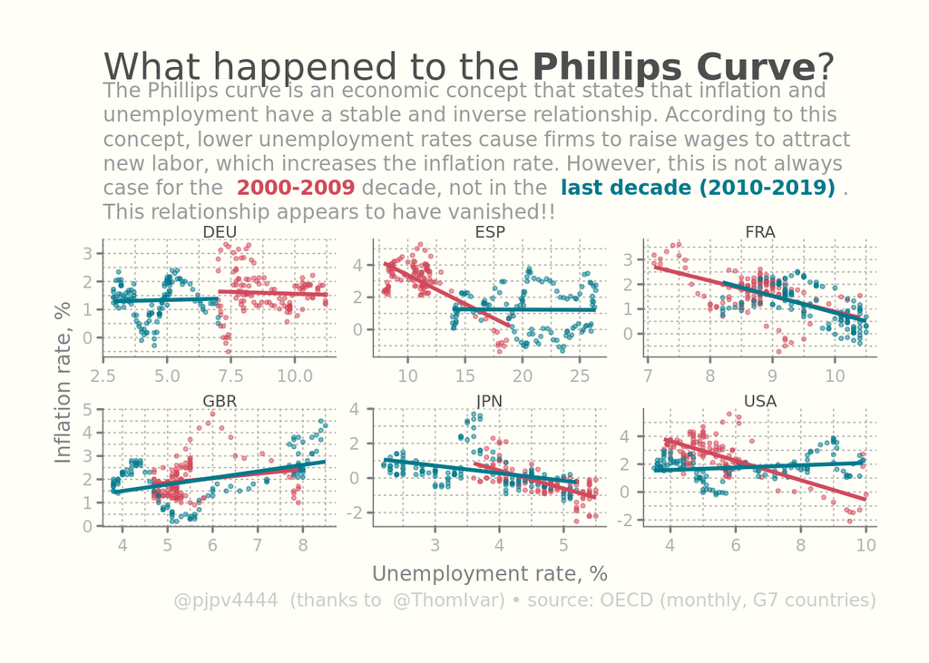

```r
#- SEGUNDA parte (del script) --------------------------------------------------
#- hacemos el gráfico para varios países ---------------------------------------
my_paises <- c("ESP", "FRA", "GBR", "DEU", "USA", "JPN")
my_periodos <- c("2000-2009", "2010-2019")

df_paises <- df %>%
  dplyr::filter(place %in% my_paises) %>%
  dplyr::filter(group %in% my_periodos)

#- plot feo para luego hacer un facetting
p0 <- ggplot(df_paises, aes(x = rate, y = cpi, color = group)) +
  geom_point(alpha = 0.5, size = 0.75) +
  geom_smooth(method = 'lm', se = FALSE, linetype = 1) +
  scale_color_manual(values = c(  '#d1495b', '#00798c', '#099205','#8e0592'))

#p0
#p0 +  facet_wrap(vars(place))

p1 <- p0 +
  facet_wrap(vars(place), scales = "free")  +
  labs(title = "What happened to the <b>Phillips Curve</b>? ",
       subtitle = "The Phillips curve is an economic concept that states that inflation
       and unemployment have a stable and inverse relationship. According to this concept,
       lower unemployment rates cause firms to raise wages to attract new labor,
       which increases the inflation rate. However, this is not always case for the <b style='color:#d1495b'>
       2000-2009</b> decade, not in the <b style='color:#00798c'>
       last decade (2010-2019) </b>. This relationship appears to have vanished!!",
       caption = "@pjpv4444  (thanks to  @ThomIvar) • source: OECD (monthly, G7 countries)",
       x = 'Unemployment rate, %',
       y = 'Inflation rate, %') +
  theme_void() +
  theme(text = element_text('American Typewriter', color = 'grey30'),
    legend.position = 'none',
    plot.title = element_textbox_simple(size = 20, margin = margin(b = 0.15, unit = 'cm')),
    plot.subtitle = element_textbox_simple(size = 11, color = 'grey60',
                                           margin = margin(b = 0.25, unit = 'cm')),
    plot.background = element_rect(fill = '#fffef7', color = '#fffef7'),
    plot.caption = element_text(size = 10, color = 'grey80'),
    plot.margin = margin(1, 1, 1, 1, 'cm'),
    panel.grid = element_line(color = 'grey70', linetype = 'dotted'),
    axis.title = element_text(margin = margin(t = 0.2, r = 0.2, unit = 'cm'), color = 'grey50'),
    axis.title.y = element_text(angle = 90),
    axis.text = element_text(color = 'grey70', size = 9,
                             margin = margin(t = 0.1, r = 0.1, unit = 'cm')),
    axis.line = element_line(color = 'grey50'),
    axis.ticks = element_line(color = 'grey50', size = 0.6),
    axis.ticks.length = unit(0.10, 'cm'))


p1
```

# Tablas

Nos falta hacer una tabla, así que, por ejemplo, hacemos tabla de la inflación en el último mes que tengamos datos.

```r
df_tabla <- inflation_orig %>%
  dplyr::filter(FREQUENCY == "M" & MEASURE == "AGRWTH") %>%
  select(place = LOCATION, date = TIME, cpi = Value, tipo_inf = SUBJECT) %>%
  #filter(date == max(date, na.rm = TRUE)) %>%
  filter(date == "2023-02") %>%
  filter(place %in% my_paises) %>%
  pivot_wider(names_from = tipo_inf, values_from = cpi) %>%
  arrange(desc(TOT)) %>%
  select(1, TOT, everything()) %>%
  select(-date)
```

- Primero con el paquete `gt`

```r
gt::gt(df_tabla)
```

| place | TOT | ENRG | FOOD | TOT_FOODENRG |
| --- | --- | --- | --- | --- |
| GBR | 9.200000 | 48.3000000 | 18.200000 | 5.700000 |
| DEU | 8.679245 | 19.9795800 | 20.724910 | 5.863983 |
| FRA | 6.278686 | 13.9535200 | 15.782350 | 3.572005 |
| USA | 6.035613 | 5.1917500 | 10.149780 | 5.537755 |
| ESP | 6.034309 | -8.8655630 | 16.635400 | 5.187600 |
| JPN | 3.300000 | -0.6866953 | 7.692307 | 2.332657 |

- Ahora con el paquete `DT`

```r
DT::datatable(df_tabla)
```

|  | place | TOT | ENRG | FOOD | TOT_FOODENRG |
| --- | --- | --- | --- | --- | --- |
| 1 | GBR | 9.2 | 48.3 | 18.2 | 5.7 |
| 2 | DEU | 8.679245 | 19.97958 | 20.72491 | 5.863983 |
| 3 | FRA | 6.278686 | 13.95352 | 15.78235 | 3.572005 |
| 4 | USA | 6.035613 | 5.19175 | 10.14978 | 5.537755 |
| 5 | ESP | 6.034309 | -8.865563 | 16.6354 | 5.1876 |
| 6 | JPN | 3.3 | -0.6866953 | 7.692307 | 2.332657 |